# Week 5 - Workshop Activities

Welcome to the Week 5 workshop on Judgements, Decision Making, and Heuristics.

Hopefully you will have completed the survey before completing the other learning activities. This page will present the results so that you can compare our MMU Second Year Cognitive Psychology data with Kahneman and Tversky’s results from 1979 and see if they replicated!

# 1 Study 1: Ruggeri et al (2020) replication

The analysis replicates Ruggeri et al (2020) who looked at individual items, and also compared pairs of questions to see whether the effects predicted by Prospect Theory (certainty, reflection, isolation, etc) replicated. Below will be a brief summary of these effects, followed by graphs of our data.

### 1.0.1 Certainty

Certainty is a bias towards a definite reward over a lottery, even when the utility of the lottery is greater than the definite reward.

#### 1.0.1.1 Example Questions

Which do you prefer:

1: A 33% chance at 2,500, a 66% chance at 2,400, and a 1% chance of 0 Guaranteed 2,400

2: A 33% chance of 2,500 (67% chance of 0) A 34% chance of 2,400 (66% chance of 0)

### 1.0.2 Reflection

Reflection is a reversal of the certainty bias, where people are more likely to take a risk if there is a small chance that they will lose nothing - i.e. people take a lottery, even when the loss is greater than the certain loss.

#### 1.0.2.1 Example Questions

A 20% chance of losing 4,000 (80% chance of losing 0) A 25% chance of losing 3,000 (75% chance of losing 0)

### 1.0.3 Overweighting small probabilities

People are less swayed by changes in small probabilities than they are by changes in large probabilities. For instance, a difference between a 0.1% chance, and 0.2% chance is deemed smaller than a difference between 45% and 90% - even though they are both double odds.

#### 1.0.3.1 Example Questions

9: A 45% chance of losing 6,000 (55% chance of losing 0) A 90% chance of losing 3,000 (10% chance of losing 0)

10: A 0.1% chance of losing 6,000 (A 99.9% chance of losing 0) A 0.2% chance of losing 3,000 (A 99.8% chance of losing 0)

### 1.0.4 Framing

Framing is where decisions are swayed by how a question is asked: for instance, people are more likely to take a sure reward when the alternative is presented as a loss, than when it is presented as a gain.

#### 1.0.4.1 Example Questions

12: Imagine we gave you 1,000 right now to play a game. Which option would you prefer?

- A 50% chance to gain an additional 1,000 (50% chance of gaining 0 beyond what you already have)
- A 100% guarantee of gaining an additional 500

13: Imagine we gave you 2,000 right now to play a game. Which option would you prefer?

- A 50% chance you will lose 1,000 (50% chance of losing 0)
- A 100% chance you will lose 500

## 1.1 Results

Figures 1.1 & 1.2 are equivalent to the Ruggeri et al (2020) figures 1a & 3a.

The black squares in Figure 1.1 show the Kahneman and Tversky (1979) findings, the dashed line shows the point at which any decisions are likely to have been made at random (50% chance that a person selected A or B - so this is the null effect). Above the dashed line, the blue diamonds indicate that Option A was selected above chance, and the red diamonds indicate that option A was not selected significantly more than option B. Below the dashed line, blue diamonds indicate that Option B was selected over Option A above chance, whereas red diamonds indicate that neither were preferred.

If a blue diamond and a black square are in the same half of the plot (i.e. both above or below the dashed line) this indicates a replicated effect in the same direction, whereas if a blue diamond and a black square are in opposite halves of the plot this indicates that we found the opposite effect to Kahneman and Tversky!

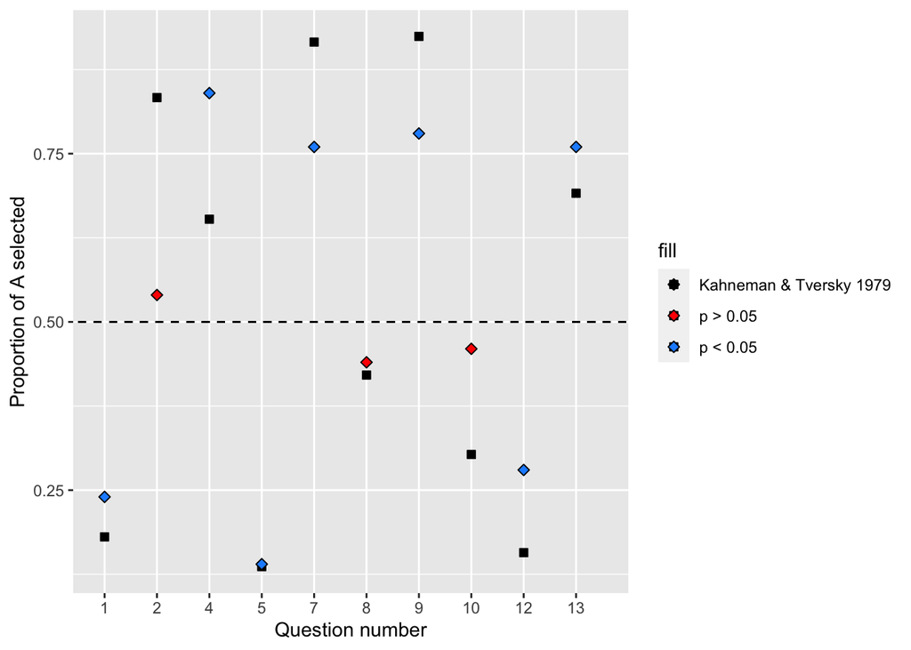

Figure 1.1: By item replication.

In plot 2, the colour of the dot indicates the effect of interest. For instance, the red dots show the certainty effect - so they compare questions in which the certain option had less utility than the gamble, with an item in which both options included gambles. Red dots above the dashed line indicate that the certain option was selected more often that the gamble; Red dots below the dashed line indicate that the gamble was selected more often than the certain value. Black triangle provide the original data from Kahneman and Tversky.

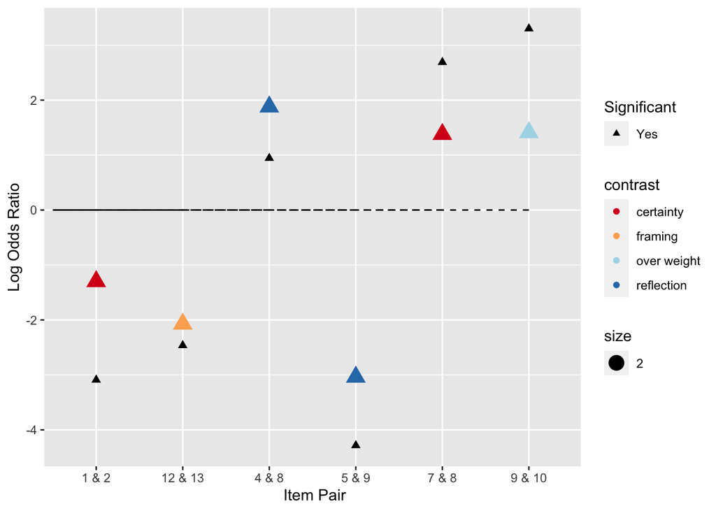

Figure 1.2: Contrast replication.

## 1.2 Questions

The effect for each item is presented with the effect from Kahneman and Tversky.

Which items replicated?

Ruggeri et al (2020) compared items to investigate different effects predicted by Prospect Theory – which effects replicated?

## 1.3 SUMMARY

The table below provides a brief summary of the tests that were run on the contrasts.

Table 1.1:

[output not shown]

# 2 Study 2: Replication of Sanders et al (2020)

We also replicated the study by Sanders et al (2020).

You were presented with one of two statements about COVID-19 restrictions; they were framed either as a loss (1000 people could die), or as a gain (1000 people could survive).

The results are as follows.

### 2.0.1 Stockpiling

The t-test on responses to the question “How often do you intend Stockpiling food and other household goods?” was t(35) = 2.56, p = 0.01, 95% CI = [0.19, 1.62], Cohen’s d = 0.73. Figure 2.1 visualises this.

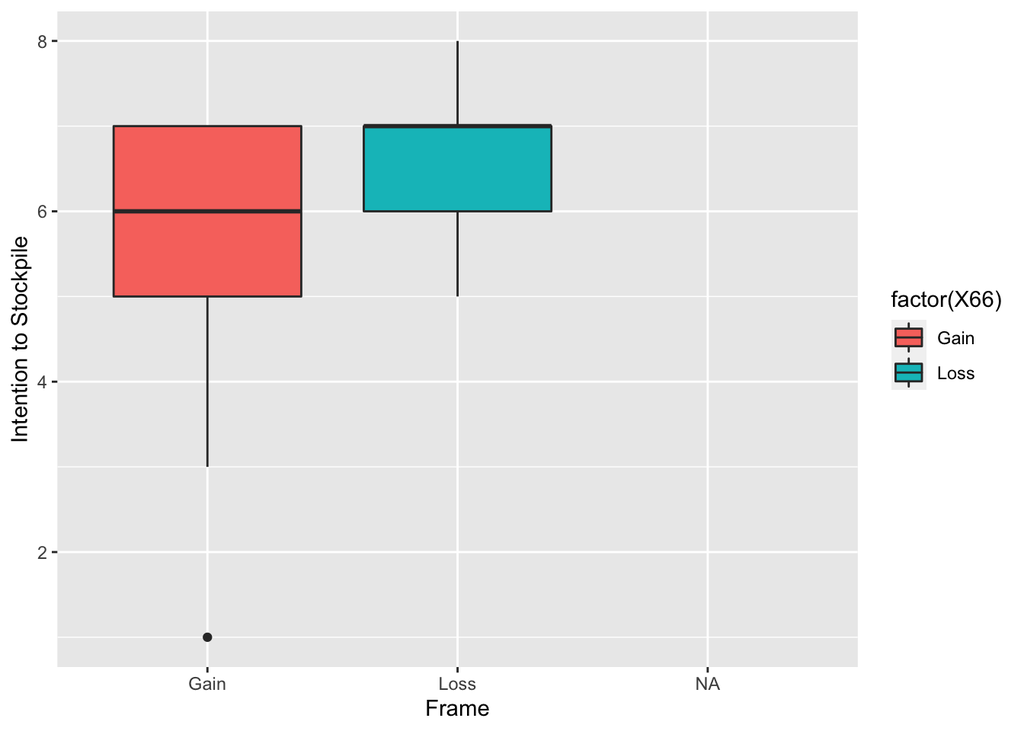

Figure 2.1: Stockpiling

### 2.0.2 Social Distancing

The t-test on responses to the question “How often do you intend Social distancing from others apart from those in your household?” was t(46) = 0.31, p = 0.76, 95% CI = [-0.96, 1.31], Cohen’s d = 0.09. Figure 2.2 visualises this.

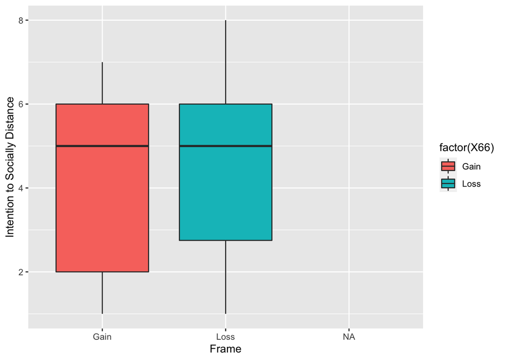

Figure 2.2: Social Distancing

## 2.1 Questions

Sanders et al (2020) argued that framing effects do not affect intentions to follow advisory behaviours; do our data corroborate this? Are these findings consistent with Sanders et al (2020)?

# 3 Kahneman and Tversky Questions

Which option do you prefer?

1: A 33% chance at 2,500, a 66% chance at 2,400, and a 1% chance of 0 Guaranteed 2,400

2: A 33% chance of 2,500 (67% chance of 0) A 34% chance of 2,400 (66% chance of 0)

4: A 20% chance of 4,000 (80% chance of 0) 25% chance of 3,000 (75% chance of 0)

5: A 45% chance of 6,000 (55% chance of 0) 90% chance of 3,000 (10% chance of 0)

7: An 80% chance of losing 4,000 (20% chance of losing 0) A 100% guarantee of losing 3,000

8: A 20% chance of losing 4,000 (80% chance of losing 0) A 25% chance of losing 3,000 (75% chance of losing 0)

9: A 45% chance of losing 6,000 (55% chance of losing 0) A 90% chance of losing 3,000 (10% chance of losing 0)

10: A 0.1% chance of losing 6,000 (A 99.9% chance of losing 0) A 0.2% chance of losing 3,000 (A 99.8% chance of losing 0)

12: Imagine we gave you 1,000 right now to play a game. Which option would you prefer?

- A 50% chance to gain an additional 1,000 (50% chance of gaining 0 beyond what you already have)
- A 100% guarantee of gaining an additional 500

13: Imagine we gave you 2,000 right now to play a game. Which option would you prefer?

- A 50% chance you will lose 1,000 (50% chance of losing 0)
- A 100% chance you will lose 500